# Wprowadzenie

Skrypt pokazuje jak użyć pakietu SciKit do wizualizacji danych na przykładzie zestawu danych zawierającego obrazy cyfr pisanych ręcznie.

```python
%matplotlib inline

import numpy as np
import matplotlib.pyplot as plt

from sklearn import (datasets, decomposition, ensemble, manifold, random_projection)
```

```python
def plot_digits(X, y):
    X = (X - np.min(X, 0)) / (np.max(X, 0) - np.min(X, 0))

    plt.figure(figsize=(12, 9))

    for i in range(X.shape[0]):
        plt.text(X[i, 0], X[i, 1], str(y[i]), color=plt.cm.Set1(0.1*y[i]), fontdict={'weight':'bold', 'size':8})

    plt.xticks([])
    plt.yticks([])
    plt.show()
```

# Wczytanie danych

```python
digits = datasets.load_digits()
X = digits.data
y = digits.target
N, d = X.shape
```

# Wyświetlenie przykładowych cyfr

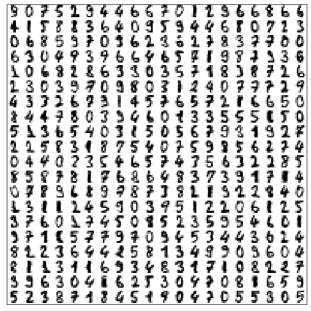

```python
M = 20
image = np.zeros((10 * M, 10 * M))
order = np.random.permutation(N)
for i in range(M):
    for j in range(M):
        image[10*i+1:10*i+9, 10*j+1:10*j+9] = X[order[i*M+j], :].reshape((8, 8))

plt.figure(figsize=(9, 9))
plt.imshow(image, cmap=plt.cm.binary)
plt.xticks([])
plt.yticks([])
plt.show()
```

# Rzut na dwie losowo wybrane osie

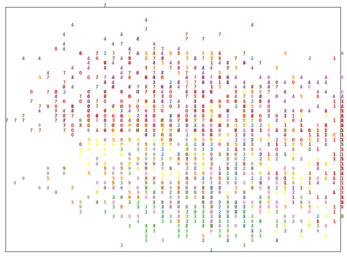

```python
X_projected = random_projection.SparseRandomProjection(n_components=2).fit_transform(X)
plot_digits(X_projected, digits.target)
```

# Principal Component Analysis (PCA)

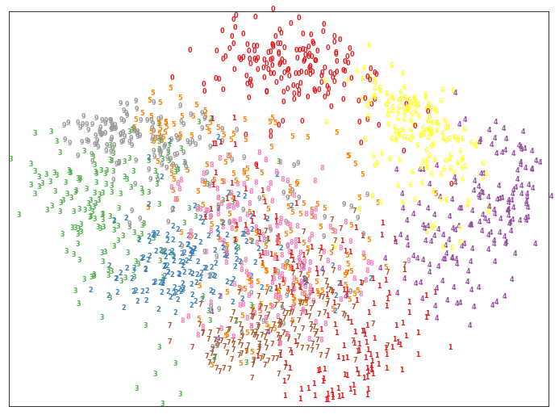

```python
X_pca = decomposition.PCA(n_components=2).fit_transform(X)
plot_digits(X_pca, digits.target)
```

# Kernel Principal Component Analysis (KPCA)

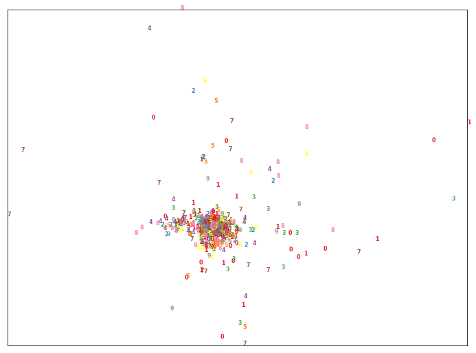

```python
X_kpca = decomposition.KernelPCA(n_components=2, kernel='rbf', gamma=10).fit_transform(X)
plot_digits(X_kpca, digits.target)
```

# Kernel PCA - polynomial kernel

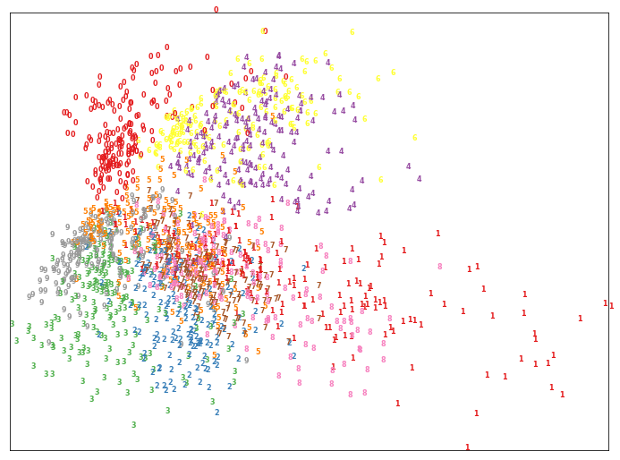

```python
X_kpca = decomposition.KernelPCA(n_components=2, kernel='poly', degree=4).fit_transform(X)
plot_digits(X_kpca, digits.target)
```

# Isomap

K najbliższych sąsiadów  
d wyjściowych wymiarów  
mapujemy na macierz odległości, ale liczonych tylko przechodząc poprzez najbliższych sąsiadów

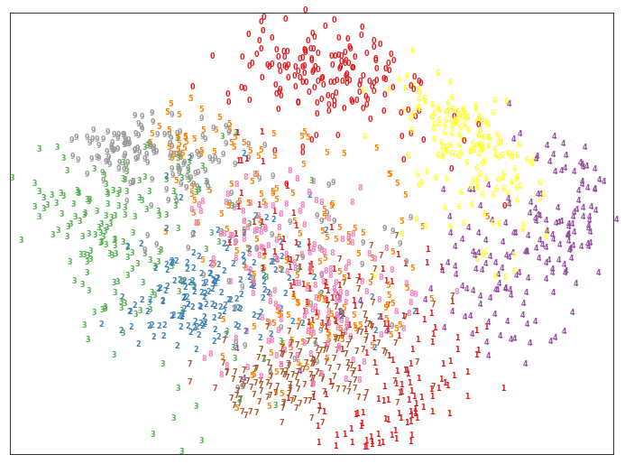

```python
X_iso = manifold.Isomap(1796, n_components=2, eigen_solver='arpack').fit_transform(X)
plot_digits(X_iso, digits.target)
```

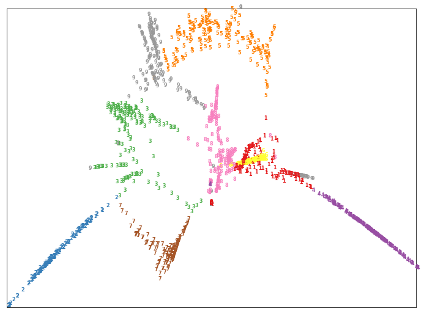

```python
X_iso = manifold.Isomap(2, n_components=2, eigen_solver='dense').fit_transform(X)
plot_digits(X_iso, digits.target)
```

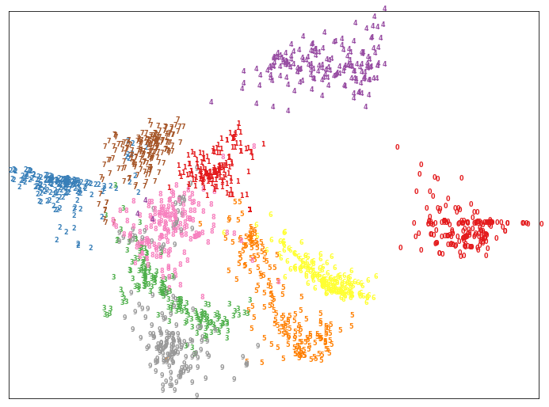

```python
X_iso = manifold.Isomap(4, n_components=2, eigen_solver='dense').fit_transform(X)
plot_digits(X_iso, digits.target)
```

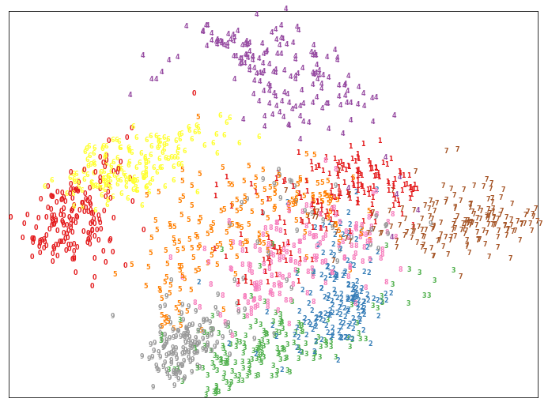

```python
X_iso = manifold.Isomap(40, n_components=2, eigen_solver='dense').fit_transform(X)
plot_digits(X_iso, digits.target)
```

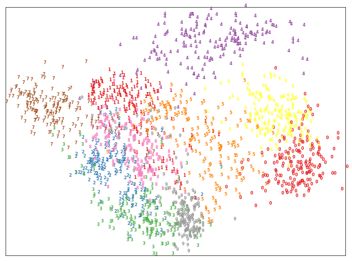

```python
X_iso = manifold.Isomap(30, n_components=2, p=4).fit_transform(X)
plot_digits(X_iso, digits.target)
```

# Locally Linear Embedding (LLE)

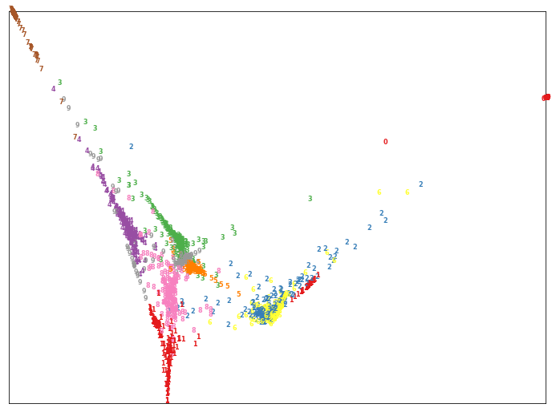

```python
X_lle = manifold.LocallyLinearEmbedding(10, n_components=2, reg=0.001).fit_transform(X)
plot_digits(X_lle, digits.target)
```

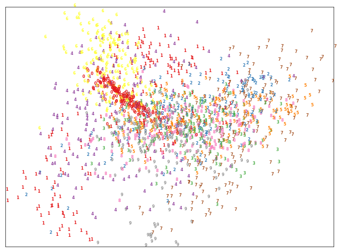

```python
X_lle = manifold.LocallyLinearEmbedding(100, n_components=2).fit_transform(X)
plot_digits(X_lle, digits.target)
```

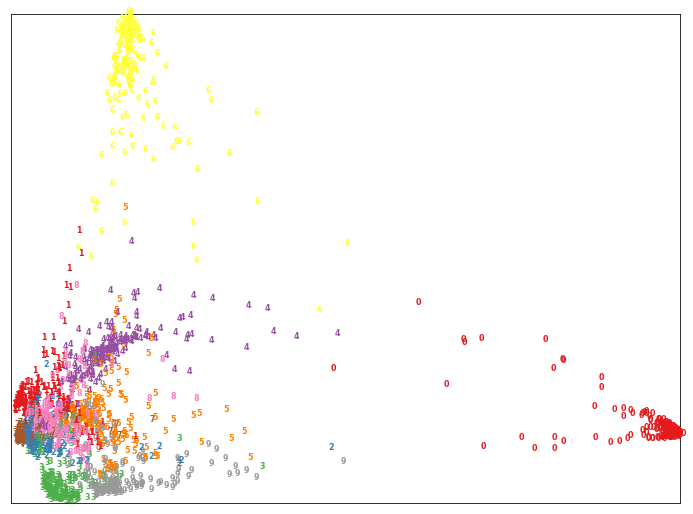

```python
X_lle = manifold.LocallyLinearEmbedding(100, n_components=2, reg=0.1).fit_transform(X)
plot_digits(X_lle, digits.target)
```

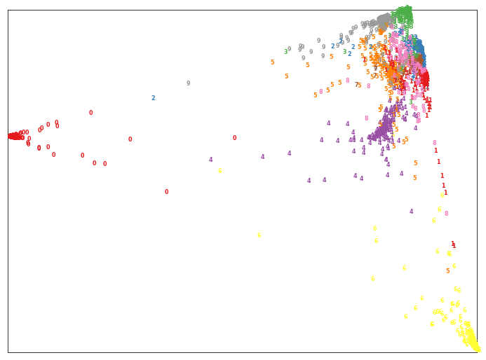

```python
# X_lle = manifold.LocallyLinearEmbedding(100, n_components=2, reg=0.000001).fit_transform(X)
X_lle = manifold.LocallyLinearEmbedding(100, n_components=2, reg=5).fit_transform(X)
plot_digits(X_lle, digits.target)
```

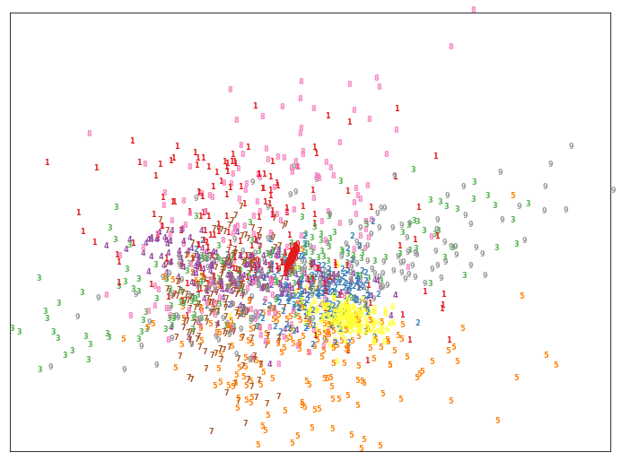

```python
X_lle = manifold.LocallyLinearEmbedding(30, n_components=2, reg=0.001).fit_transform(X)
plot_digits(X_lle, digits.target)
```

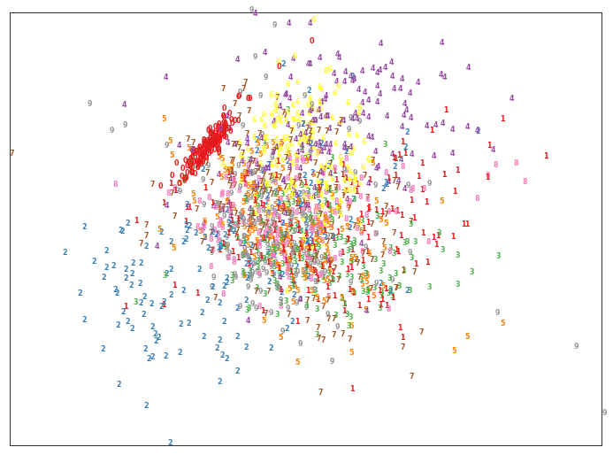

```python
X_lle = manifold.LocallyLinearEmbedding(30, n_components=2, reg=0.00000000000000000001).fit_transform(X)
plot_digits(X_lle, digits.target)
```

# Modified LLE

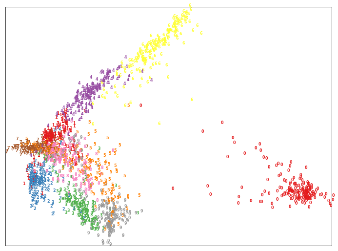

```python
X_lle = manifold.LocallyLinearEmbedding(
    100, method='modified', n_components=2).fit_transform(X)
plot_digits(X_lle, digits.target)
```

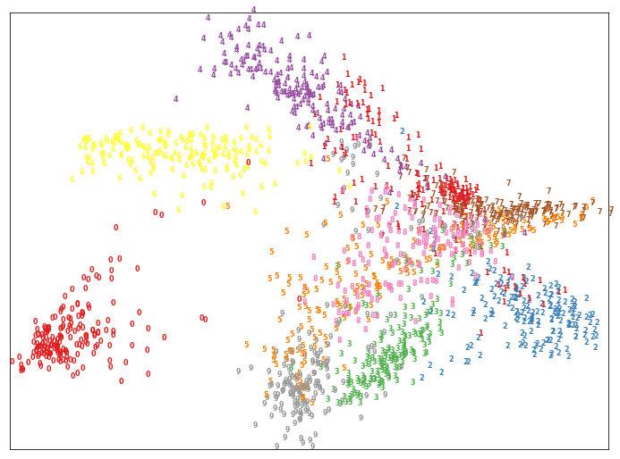

```python
X_lle = manifold.LocallyLinearEmbedding(
    150, method='modified', n_components=2).fit_transform(X)
plot_digits(X_lle, digits.target)
```

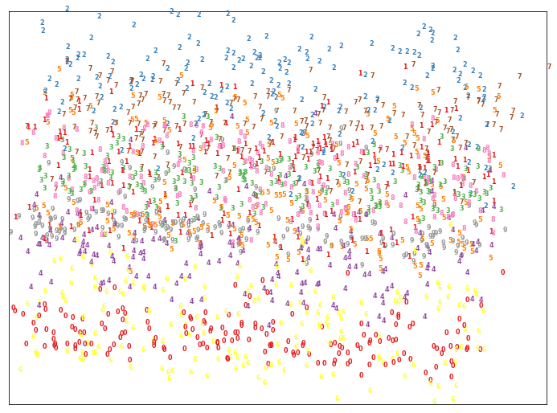

```python
X_lle = manifold.LocallyLinearEmbedding(
    190, method='modified', n_components=2, n_jobs=-1).fit_transform(X)
plot_digits(X_lle, digits.target)
```

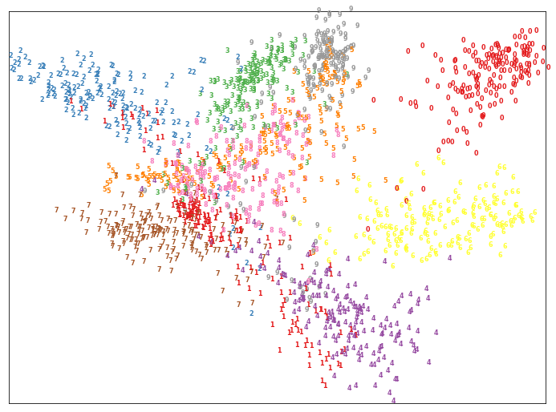

```python
X_lle = manifold.LocallyLinearEmbedding(
    200, method='modified', n_components=2, n_jobs=-1).fit_transform(X)
plot_digits(X_lle, digits.target)
```

# Hessian LLE

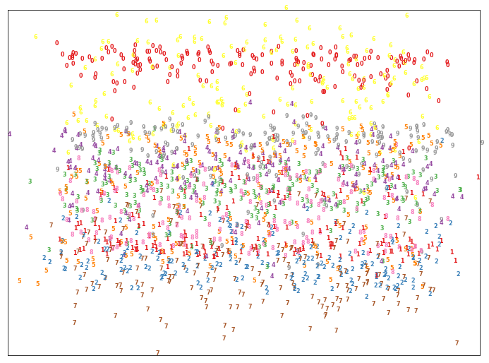

```python
X_lle = manifold.LocallyLinearEmbedding(
    200, method='hessian', n_components=2, n_jobs=-1).fit_transform(X)
plot_digits(X_lle, digits.target)
```

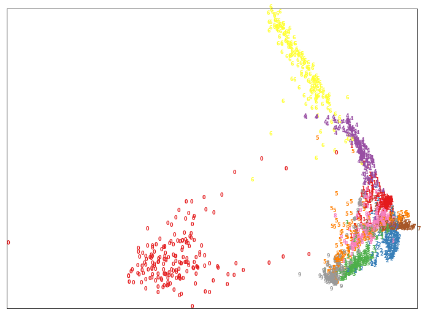

```python
X_lle = manifold.LocallyLinearEmbedding(
    100, method='hessian', n_components=2, n_jobs=-1).fit_transform(X)
plot_digits(X_lle, digits.target)
```

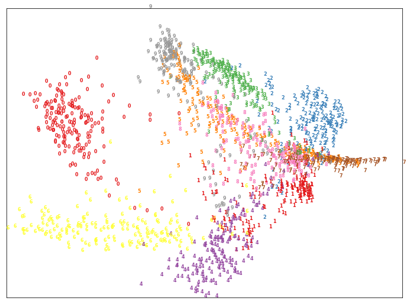

```python
X_lle = manifold.LocallyLinearEmbedding(
    170, method='hessian', n_components=2, n_jobs=-1).fit_transform(X)
plot_digits(X_lle, digits.target)
```

# Multidimensional Scaling (MDS)

```
[Parallel(n_jobs=-1)]: Using backend LokyBackend with 4 concurrent workers.
[Parallel(n_jobs=-1)]: Done   1 tasks      | elapsed:   54.8s
[Parallel(n_jobs=-1)]: Done   2 out of   8 | elapsed:   55.0s remaining:  2.7min
[Parallel(n_jobs=-1)]: Done   3 out of   8 | elapsed:   55.1s remaining:  1.5min
[Parallel(n_jobs=-1)]: Done   4 out of   8 | elapsed:   55.3s remaining:   55.3s
[Parallel(n_jobs=-1)]: Done   5 out of   8 | elapsed:  1.8min remaining:  1.1min
[Parallel(n_jobs=-1)]: Done   6 out of   8 | elapsed:  1.8min remaining:   36.2s
[Parallel(n_jobs=-1)]: Done   8 out of   8 | elapsed:  1.8min remaining:    0.0s
[Parallel(n_jobs=-1)]: Done   8 out of   8 | elapsed:  1.8min finished
```

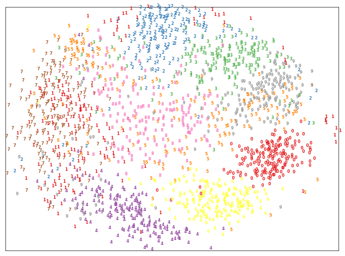

```python
X_mds = manifold.MDS(n_components=2, n_init=8, n_jobs=-1, verbose=42).fit_transform(X)
plot_digits(X_mds, digits.target)
```

[output not shown]

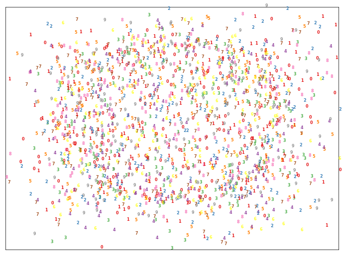

```python
X_mds = manifold.MDS(n_components=2, metric=False, n_init=64, n_jobs=-1, verbose=42).fit_transform(X)
plot_digits(X_mds, digits.target)
```

# t-distributed Stochastic Neighbor Embedding (t-SNE)

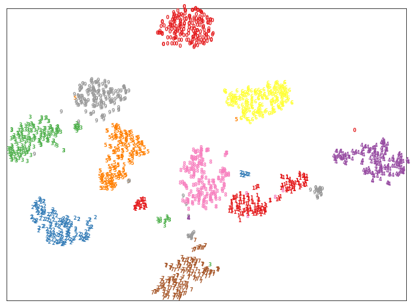

```python
X_tsne = manifold.TSNE(n_components=2, init='pca').fit_transform(X)
plot_digits(X_tsne, digits.target)
```

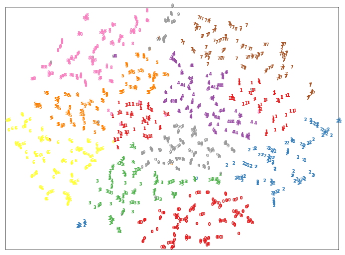

```python
X_tsne = manifold.TSNE(n_components=2, perplexity=2).fit_transform(X)
plot_digits(X_tsne, digits.target)
```

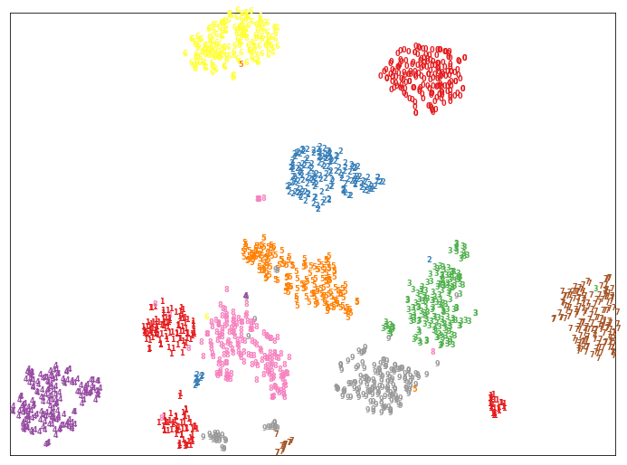

```python
X_tsne = manifold.TSNE(n_components=2, perplexity=40, early_exaggeration=1).fit_transform(X)
plot_digits(X_tsne, digits.target)
```

# Zadanie 7.

Porównujemy klasyfikator KNN na różnych transformacjach zbioru danych.

Wartości hiperparametrów poszczególnych algorytmów pochodzą z "najlepszych" wizualnie kombinacji narysowanych powyżej.

## Małe podsumowanie wyników

Jak można się było spodziewać, wszelkie[1] redukcje wymiarowości jedynie pogarszają wyniki KNN - w końcu komputer nie potrzebuje 2 lub 3 wymiarów by wnioskować o danych - wielotysięczne przestrzenie są dla niego równie zrozumiałe (pomijając wymagany czas obliczeń, oczywiście), a wypróbowane redukcje nieuchronnie pozbawiają nas części informacji o lokalnej strukturze i niuansach rozważanych danych.

Zaskakującym wyjątkiem jest t-SNE - w wypróbowanych parametrach osiągnął o okolo 1% lepsze wyniki niż wyjściowy zbiór danych! Zanim jednak przejdziemy do wniosku że to algorytm, którego warto byłoby użyć jako preprocessingu zauważmy dwa zasadnicze problemy:

- Zjawisko jest ciekawe, jednak nie mamy żadnej gwarancji że inne zbiory danych dadzą się w tak ładny (i wizualnie, i, jak widać, algorytmicznie) sposób przetworzyć - w tym przypadku t-SNE wykorzystał fakt całkiem dobrych wyników klasyfikacji na podstawie klastrów/sąsiadów, jego ułożenie sąsiadów na rozkładach prawdopodobieństwa dystansów jedynie wzmocniło ten efekt
- Znając cały zbiór, którego klasy chcielibyśmy przewidzieć rzeczywiście możemy wypróbować użycie t-SNE - w prawdziwym życiu jednak możemy jedynie aproksymować zanurzenie nowych, nieznanych wcześniej punktów, a więc najważniejszej rzeczy jaką nasz kiedykolwiek klasyfikator zobaczy

[1] prawie

```python
import pandas as pd
from sklearn.model_selection import (
    cross_val_score,
    cross_validate
)
from sklearn.neighbors import KNeighborsClassifier
```

```python
DATASETS_TRANSFORMATIONS = {
    'Bez zmian': X,
    'PCA': decomposition.PCA(n_components=2).fit_transform(X),
    'Kernel PCA z kernelem wielomianowym': decomposition.KernelPCA(
        n_components=2, kernel='poly', degree=4).fit_transform(X),
    'Isomap': manifold.Isomap(4, n_components=2, eigen_solver='dense').fit_transform(X),
    'LLE': manifold.LocallyLinearEmbedding(30, n_components=2, reg=0.001).fit_transform(X),
    'Modified LLE': manifold.LocallyLinearEmbedding(150, method='modified', n_components=2).fit_transform(X),
    'MDS': manifold.MDS(n_components=2, n_init=8, n_jobs=-1, verbose=42).fit_transform(X),
    't-SNE': manifold.TSNE(n_components=2, perplexity=40, early_exaggeration=1).fit_transform(X),
}
```

```
[Parallel(n_jobs=-1)]: Using backend LokyBackend with 4 concurrent workers.
[Parallel(n_jobs=-1)]: Done   1 tasks      | elapsed:   55.0s
[Parallel(n_jobs=-1)]: Done   2 out of   8 | elapsed:   55.2s remaining:  2.8min
[Parallel(n_jobs=-1)]: Done   3 out of   8 | elapsed:   55.3s remaining:  1.5min
[Parallel(n_jobs=-1)]: Done   4 out of   8 | elapsed:   55.5s remaining:   55.5s
[Parallel(n_jobs=-1)]: Done   5 out of   8 | elapsed:  1.8min remaining:  1.1min
[Parallel(n_jobs=-1)]: Done   6 out of   8 | elapsed:  1.8min remaining:   35.8s
[Parallel(n_jobs=-1)]: Done   8 out of   8 | elapsed:  1.8min remaining:    0.0s
[Parallel(n_jobs=-1)]: Done   8 out of   8 | elapsed:  1.8min finished
```

```python
results = []
```

```python
cross_val_score(KNeighborsClassifier(n_neighbors=10), X, y=digits.target)
```

```
array([0.93055556, 0.94722222, 0.96935933, 0.97771588, 0.94986072])
```

```python
for k, v in DATASETS_TRANSFORMATIONS.items():
    for K in range(1, 25+1, 2):
        print(f'doing {k} with K = {K}')
        scores = cross_val_score(KNeighborsClassifier(n_neighbors=K), v, y=digits.target)
        results.append({
            'data_transformation': k,
            'K': K,
            'avg_score': np.mean(scores),
        })
```

```python
results_df = pd.DataFrame.from_dict(results)
results_df.sort_values('avg_score', ascending=False).head(25)
```

[output not shown]

```python
results_df[results_df['data_transformation'] != 't-SNE'].sort_values('avg_score', ascending=False).head(25)
```

[output not shown]